# White wine analysis by Georg GOTTFRIED

# A short introduction into the dataset

Citation Request: This dataset is public available for research. The details are described in [Cortez et al., 2009]. Please include this citation if you plan to use this database:

P. Cortez, A. Cerdeira, F. Almeida, T. Matos and J. Reis. Modeling wine preferences by data mining from physicochemical properties. In Decision Support Systems, Elsevier, 47(4):547-553. ISSN: 0167-9236.

Available at: [@Elsevier] http://dx.doi.org/10.1016/j.dss.2009.05.016 [Pre-press (pdf)] http://www3.dsi.uminho.pt/pcortez/winequality09.pdf [bib] http://www3.dsi.uminho.pt/pcortez/dss09.bib

This data set contains 4,898 white wines with 11 variables on quantifying the chemical properties of each wine. At least 3 wine experts rated the quality of each wine, providing a rating between 0 (very bad) and 10 (very excellent). The data set has been provided by Udacity for the Nandodegree Project in exploratory data analysis (EDA). A detailed description of the dataset is available [here](https://s3.amazonaws.com/udacity-hosted-downloads/ud651/wineQualityInfo.txt)

Our guiding question is: **Which chemical properties influence the quality of white wines?**

# Univariate Plots Section

prove that X column is a unique identifier

```
## 'data.frame':    4898 obs. of  13 variables:
##  $ X                   : int  1 2 3 4 5 6 7 8 9 10 ...
##  $ fixed.acidity       : num  7 6.3 8.1 7.2 7.2 8.1 6.2 7 6.3 8.1 ...
##  $ volatile.acidity    : num  0.27 0.3 0.28 0.23 0.23 0.28 0.32 0.27 0.3 0.22 ...
##  $ citric.acid         : num  0.36 0.34 0.4 0.32 0.32 0.4 0.16 0.36 0.34 0.43 ...
##  $ residual.sugar      : num  20.7 1.6 6.9 8.5 8.5 6.9 7 20.7 1.6 1.5 ...
##  $ chlorides           : num  0.045 0.049 0.05 0.058 0.058 0.05 0.045 0.045 0.049 0.044 ...
##  $ free.sulfur.dioxide : num  45 14 30 47 47 30 30 45 14 28 ...
##  $ total.sulfur.dioxide: num  170 132 97 186 186 97 136 170 132 129 ...
##  $ density             : num  1.001 0.994 0.995 0.996 0.996 ...
##  $ pH                  : num  3 3.3 3.26 3.19 3.19 3.26 3.18 3 3.3 3.22 ...
##  $ sulphates           : num  0.45 0.49 0.44 0.4 0.4 0.44 0.47 0.45 0.49 0.45 ...
##  $ alcohol             : num  8.8 9.5 10.1 9.9 9.9 10.1 9.6 8.8 9.5 11 ...
##  $ quality             : int  6 6 6 6 6 6 6 6 6 6 ...
```

```
##    Min. 1st Qu.  Median    Mean 3rd Qu.    Max.
##       1    1225    2450    2450    3674    4898
```

```
##    Min. 1st Qu.  Median    Mean 3rd Qu.    Max.
##       1    1225    2450    2450    3674    4898
```

exclude the unique id X

analyse the dependent variable quality

```
##    Min. 1st Qu.  Median    Mean 3rd Qu.    Max.
##   3.000   5.000   6.000   5.878   6.000   9.000
```

quality ranges from 3 to 9 having a normal distribution We use a bar chart instead of histogram because of the categorial variable on the x-axis.

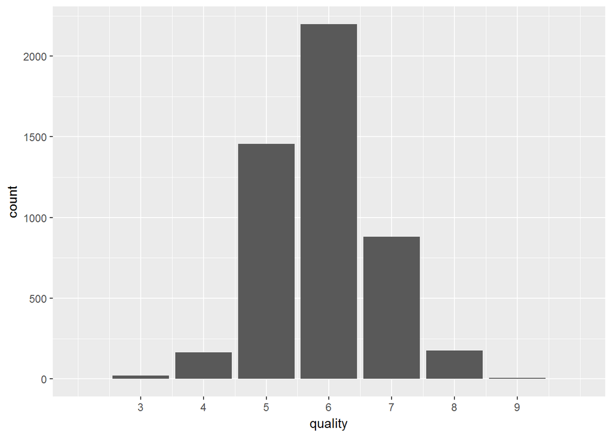

residual sugar is heavily skewed. A bimodal distribution reveals a group of fully fermented dry wines and another group of rather sweet wines:

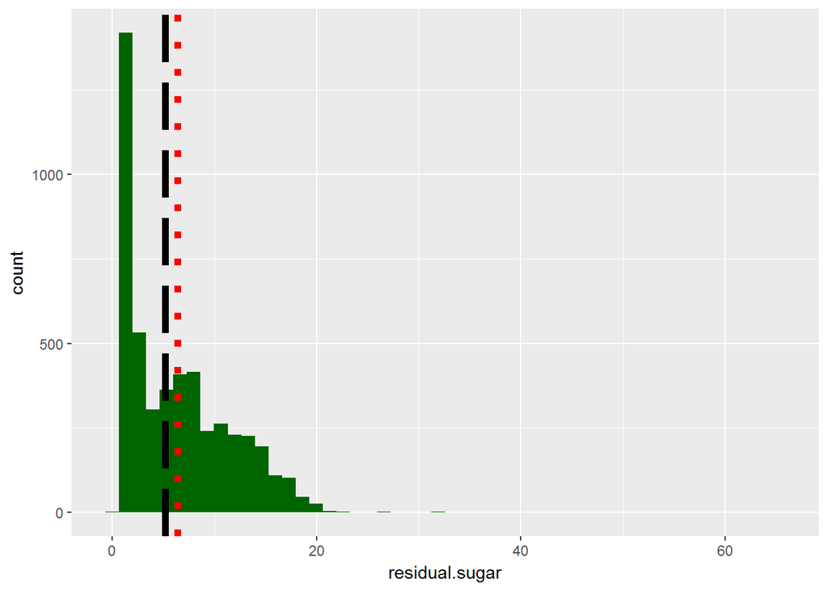

There is also a number of low alcohol wines between 9 and 10 %vol of alchol which result in a skewed distribution of the observations:

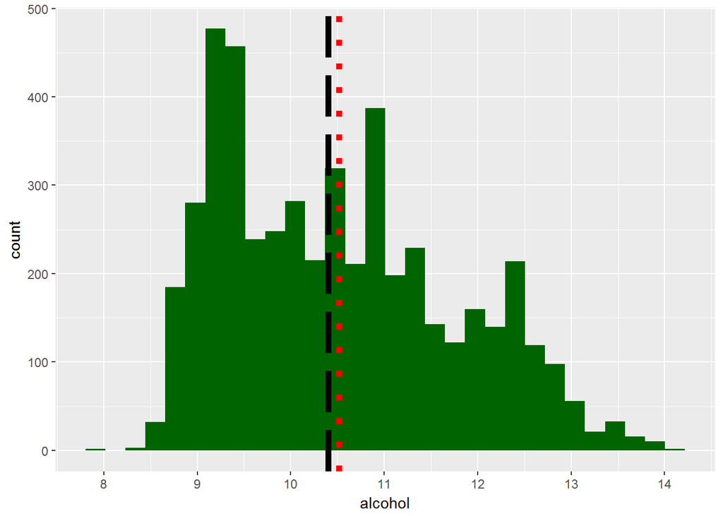

pH has an almost perfect normal distribution:

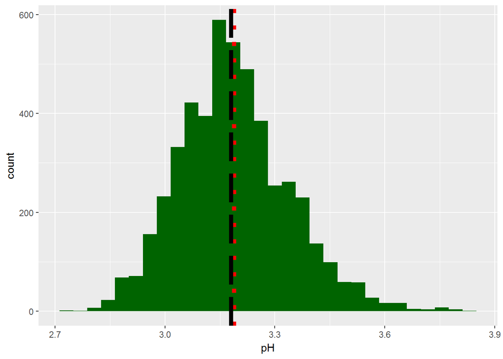

chlorides is skewed to the right because the mean value is higher than the median. We may have to normalize this using a logarithmic scale

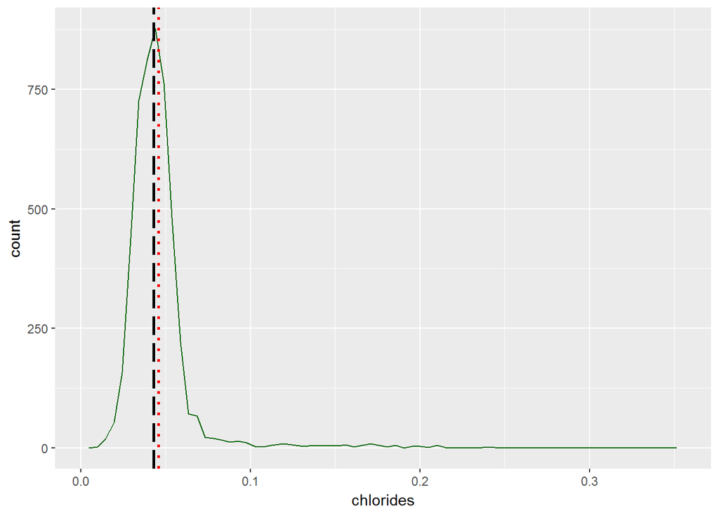

chlorides transformed on a log10 scale for better normal distribution.

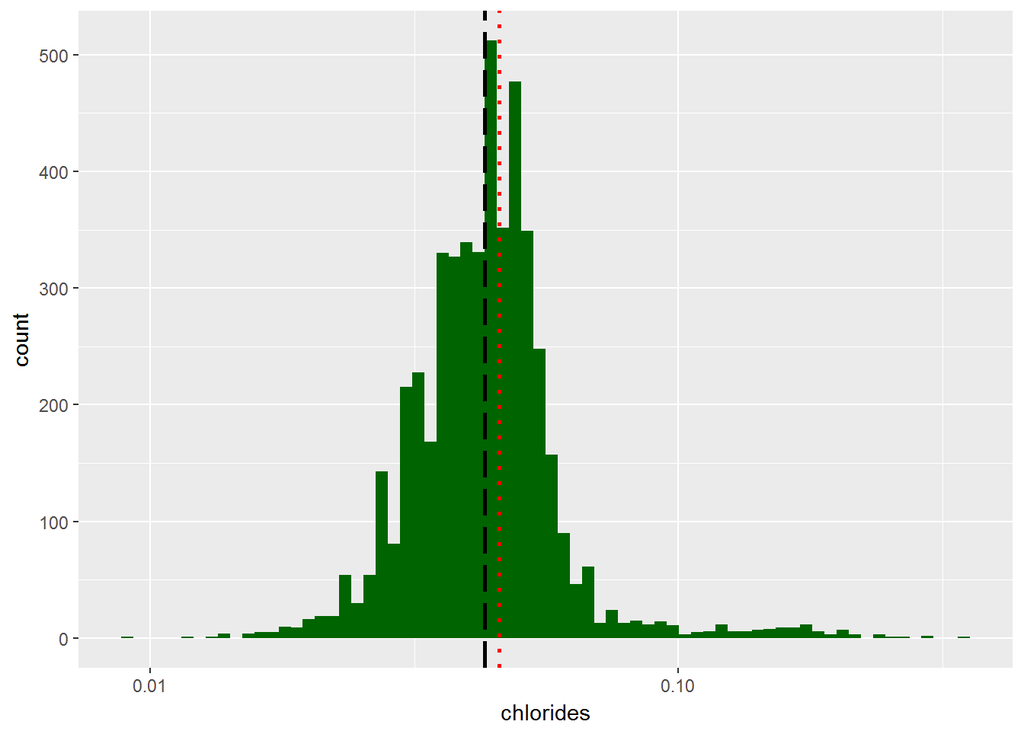

free.sulfur.dioxide has a few outliers on the right:

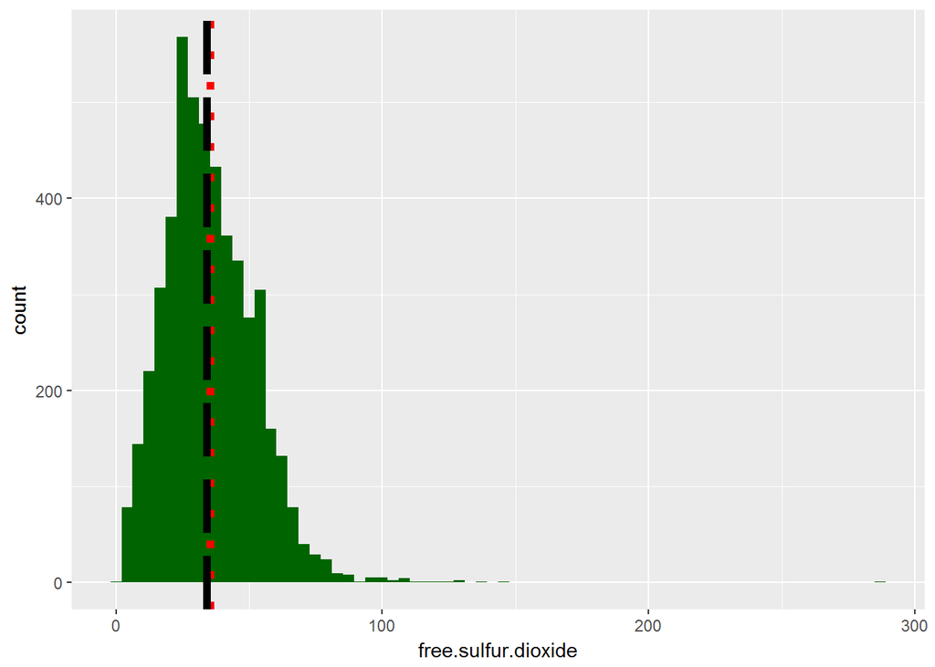

citric acid has a slightly skewed distribution with a few outliers:

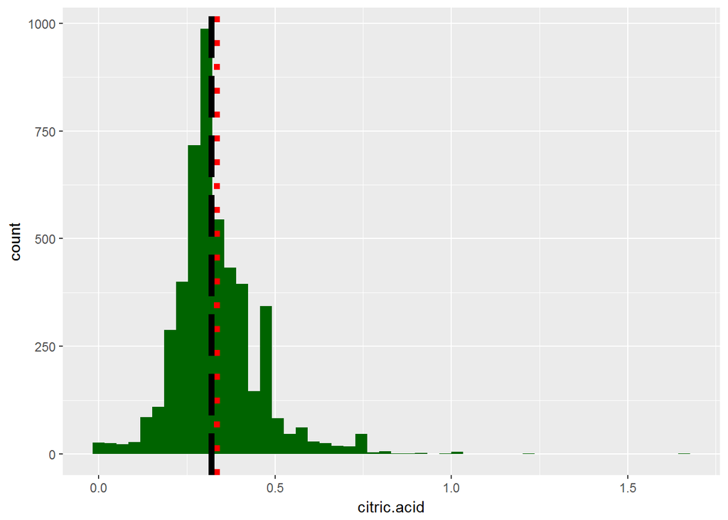

Handle Feedback: “For the univariate section, it is important to include a simple histogram ( continues feature) or a bar plot ( categorical feature) to depict the count distribution for each feature that is included in the analysis. That will allow you to examine the distribution, identify outliers and make changes to the dataset before starting the analysis.

Since you are using for the analysis the modified quality rating (but also sweet and dry), it is important to expand the univariate section to depict the count distribution for this modified feature.

Please note that the univariate section should include histograms that depict a single feature. The figures that depict the distribution of different categories can be included in the bivariate sections."

# Univariate Analysis

### What is the structure of your dataset?

The dependent variable is the quality with integer rates from 3 to 9 in the given dataset. The limited number of grades make this a candidate for an ordered factor. The chemical variables are all continuous numbers which contain often outliers

### What is/are the main feature(s) of interest in your dataset?

The main features of interest are

- residual sugar has a bimodal distribution, we may differ between sweet and dry wines
- to get rid of the outliers
- to focus on the dependent variable quality

### What other features in the dataset do you think will help support your investigation into your feature(s) of interest?

- to handle the skewed distributions if necessary
- possibly transform the quality in another way

### Did you create any new variables from existing variables in the dataset?

### Of the features you investigated, were there any unusual distributions? Did you perform any operations on the data to tidy, adjust, or change the form of the data? If so, why did you do this?

- residual sugar has a bimodal distribution, we may differ between sweet and dry wines

I omited the X column, because it’s just a unique identifier of the observation which is not relevant for the further data analysis I used the log10 algorithm on residual.sugar to detect the bimodal distribution. While nearly all of the sugar gets ferment for dry wines the residual sugar for sweet wines vary quite a lot.

# Bivariate Plots Section

convert quality integer to an ordered factor for better analysis Conceptually, factors are variables in R which take on a limited number of different values

```
##  int [1:4898] 6 6 6 6 6 6 6 6 6 6 ...
```

```
##  Ord.factor w/ 7 levels "3"<"4"<"5"<"6"<..: 4 4 4 4 4 4 4 4 4 4 ...
```

Introduce new variable quality.bucket: bad, average and outstanding

```
##         bad     average outstanding
##         183        4535         180
```

There is a bimodal distribution in residual sugar. This can be explained by the fact that there are dry (completely fermented) and sweet white wines available. They taste very different and target different audiences. We will have to consider this in further analysis.

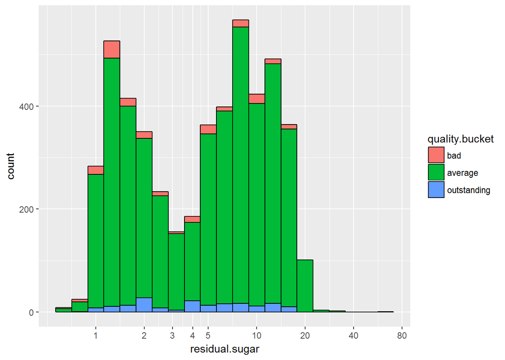

```
##    Min. 1st Qu.  Median    Mean 3rd Qu.    Max.
##   0.600   1.700   5.200   6.391   9.900  65.800
```

I decided to introduce a new variable residual.sugar.bucket to split the dataset dry wines and sweet wines

```
## 'data.frame':    4898 obs. of  15 variables:
##  $ fixed.acidity        : num  7 6.3 8.1 7.2 7.2 8.1 6.2 7 6.3 8.1 ...
##  $ volatile.acidity     : num  0.27 0.3 0.28 0.23 0.23 0.28 0.32 0.27 0.3 0.22 ...
##  $ citric.acid          : num  0.36 0.34 0.4 0.32 0.32 0.4 0.16 0.36 0.34 0.43 ...
##  $ residual.sugar       : num  20.7 1.6 6.9 8.5 8.5 6.9 7 20.7 1.6 1.5 ...
##  $ chlorides            : num  0.045 0.049 0.05 0.058 0.058 0.05 0.045 0.045 0.049 0.044 ...
##  $ free.sulfur.dioxide  : num  45 14 30 47 47 30 30 45 14 28 ...
##  $ total.sulfur.dioxide : num  170 132 97 186 186 97 136 170 132 129 ...
##  $ density              : num  1.001 0.994 0.995 0.996 0.996 ...
##  $ pH                   : num  3 3.3 3.26 3.19 3.19 3.26 3.18 3 3.3 3.22 ...
##  $ sulphates            : num  0.45 0.49 0.44 0.4 0.4 0.44 0.47 0.45 0.49 0.45 ...
##  $ alcohol              : num  8.8 9.5 10.1 9.9 9.9 10.1 9.6 8.8 9.5 11 ...
##  $ quality              : int  6 6 6 6 6 6 6 6 6 6 ...
##  $ quality.ord          : Ord.factor w/ 7 levels "3"<"4"<"5"<"6"<..: 4 4 4 4 4 4 4 4 4 4 ...
##  $ quality.bucket       : Ord.factor w/ 3 levels "bad"<"average"<..: 2 2 2 2 2 2 2 2 2 2 ...
##  $ residual.sugar.bucket: Factor w/ 2 levels "dry","sweet": 2 1 2 2 2 2 2 2 1 1 ...
```

Density of sweet wine is higher than the density of dry wine:

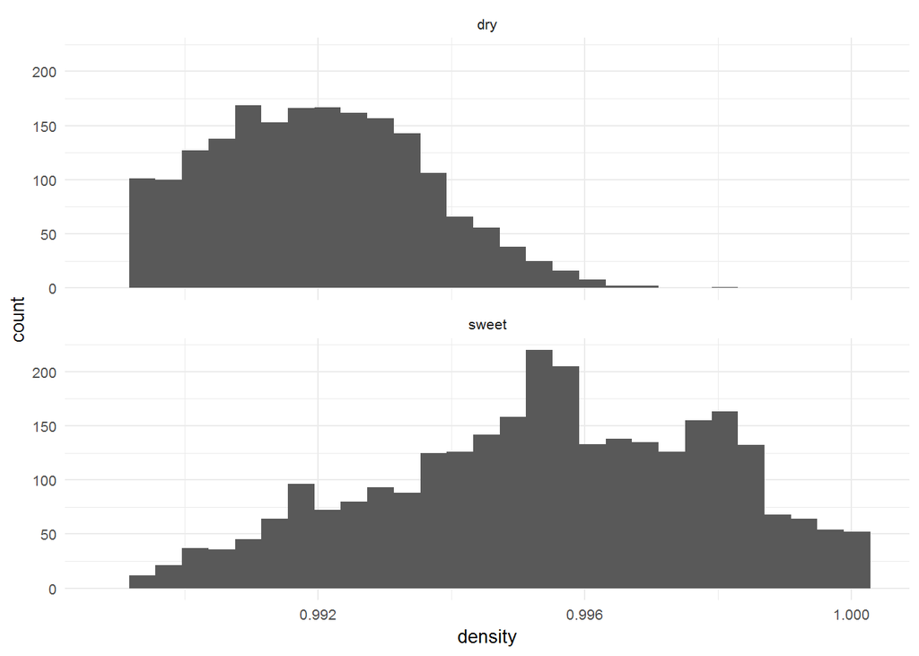

alcohol of dry wine is higher than that of sweet wine

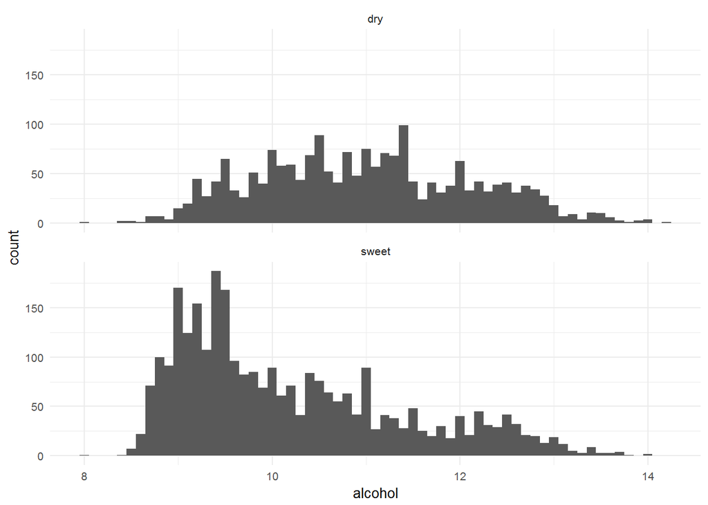

we get a better distribution of chlorides on a log10 scale

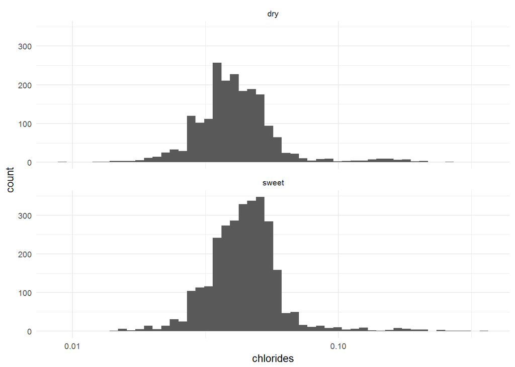

```
## 'data.frame':    4898 obs. of  16 variables:
##  $ fixed.acidity        : num  7 6.3 8.1 7.2 7.2 8.1 6.2 7 6.3 8.1 ...
##  $ volatile.acidity     : num  0.27 0.3 0.28 0.23 0.23 0.28 0.32 0.27 0.3 0.22 ...
##  $ citric.acid          : num  0.36 0.34 0.4 0.32 0.32 0.4 0.16 0.36 0.34 0.43 ...
##  $ residual.sugar       : num  20.7 1.6 6.9 8.5 8.5 6.9 7 20.7 1.6 1.5 ...
##  $ chlorides            : num  0.045 0.049 0.05 0.058 0.058 0.05 0.045 0.045 0.049 0.044 ...
##  $ free.sulfur.dioxide  : num  45 14 30 47 47 30 30 45 14 28 ...
##  $ total.sulfur.dioxide : num  170 132 97 186 186 97 136 170 132 129 ...
##  $ density              : num  1.001 0.994 0.995 0.996 0.996 ...
##  $ pH                   : num  3 3.3 3.26 3.19 3.19 3.26 3.18 3 3.3 3.22 ...
##  $ sulphates            : num  0.45 0.49 0.44 0.4 0.4 0.44 0.47 0.45 0.49 0.45 ...
##  $ alcohol              : num  8.8 9.5 10.1 9.9 9.9 10.1 9.6 8.8 9.5 11 ...
##  $ quality              : int  6 6 6 6 6 6 6 6 6 6 ...
##  $ quality.ord          : Ord.factor w/ 7 levels "3"<"4"<"5"<"6"<..: 4 4 4 4 4 4 4 4 4 4 ...
##  $ quality.bucket       : Ord.factor w/ 3 levels "bad"<"average"<..: 2 2 2 2 2 2 2 2 2 2 ...
##  $ residual.sugar.bucket: Factor w/ 2 levels "dry","sweet": 2 1 2 2 2 2 2 2 1 1 ...
##  $ chlorides.log        : num  -1.35 -1.31 -1.3 -1.24 -1.24 ...
```

Chlorides seem to be negative corelated to quality:

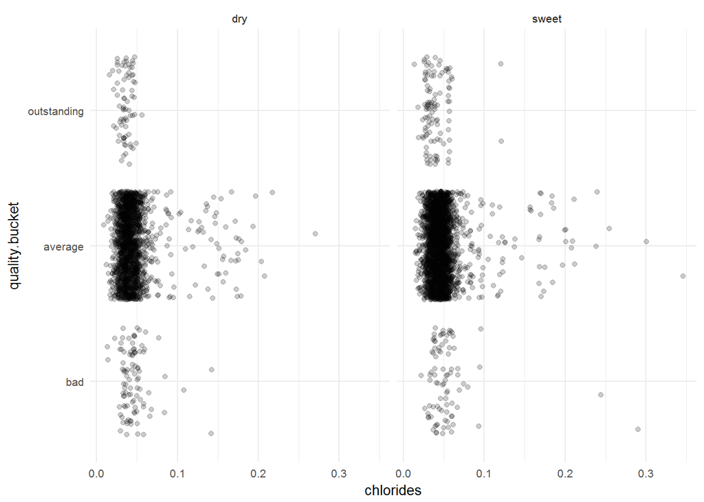

Use Feedback: “Optional, for the jitter plots, you can also add markers to show the mean values and box plot, that will make the figure more informative”

There seems to be a certain band of total.sulfur.dioxide required (50 to 220) to get an outstanding quality grade:

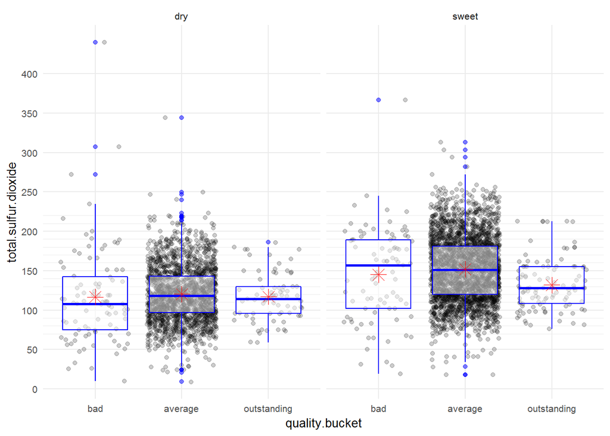

Even stronger seems to be the relationship to bound.sulfur.dioxide:

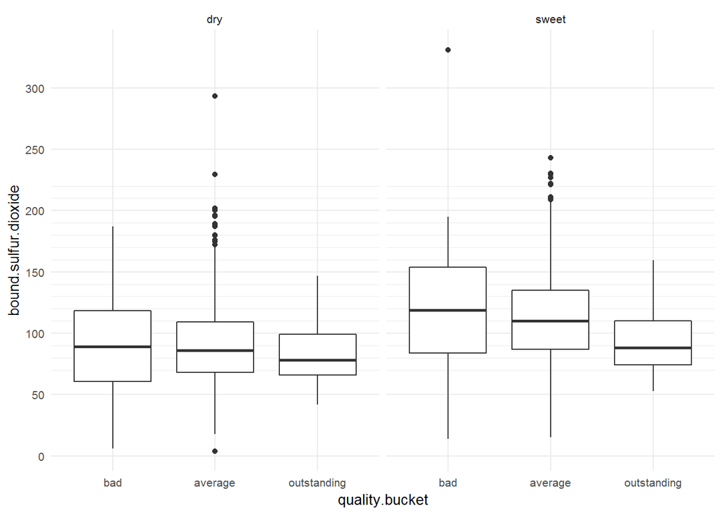

# Bivariate Analysis

### Talk about some of the relationships you observed in this part of the investigation. How did the feature(s) of interest vary with other features in the dataset?

There seems to be a certain band of total.sulfur.dioxide required (50 to 220) to get an outstanding quality grade. sweet wines allow a slightly higher band

### Did you observe any interesting relationships between the other features (not the main feature(s) of interest)?

- I added a quality.bucket with just three categories (bad, avarge, outstanding) to analyse further if there is something that makes a wine really bad or realy good apart from average.
- I added a factor residual.sugar.bucket to accomodate for sweet and dry wines

Density, residual sugar and alcohol seem to have an interrelationship. This is also confirmed in the data documentation: ‘the density of water is close to that of water depending on the percent alcohol and sugar content’

There is a strong positive relationship between

- density and residual sugar
- a negative relationship between density and alcohol
- and a negative relationship between residual sugar and alcohol

So we could drop density from further analysis

In addition there is also a positive relationship between free.sulfur.dioxide and total.sulfur.dioxide

### What was the strongest relationship you found?

strong positive relationship between density and residual sugar

# Multivariate Plots Section

Handle Feedback: “It is important to include a short discussion under each chart, explain what the chart depicts and what are your insights.

For the bivariate and multivariate sections, the discussion should also include reasonings, why you choose to include the analysis in the report? what did you expect to find? what are your insights?

The analysis includes many figures that depict comparison, trends and relations between features. It is important to include the relevant statistics in the discussion under each chart. You can include the mean median and quartiles to quantify the distribution under the histograms summary (red.wine alcohol) . The relevant correlation value under the corresponding chart to quantify the relation in the bivariate section cor (red.wine alcohol, red.wine pH).

For the multivariate scatter plots, it is important to use a sequential color table that express the fact that the feature is ordered and categorical, in addition, I strongly encourage you to add a regression line for each category to depict the separation. "

Finding relationships between quality and other variables:

Low free sulfur seems to favour bad quality but there is just a weak positive correlation between free and bound sulfur:

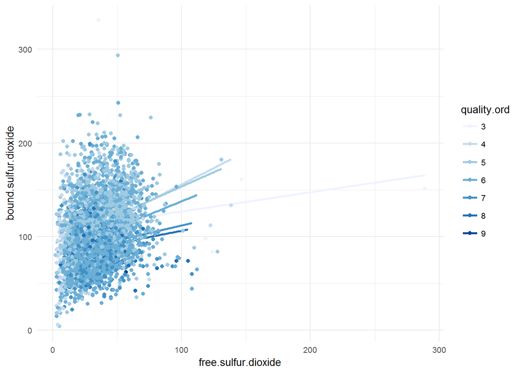

```
## [1] 0.2635373
```

a low number of chlorides with citric acid above 0.2 favours good quality wine:

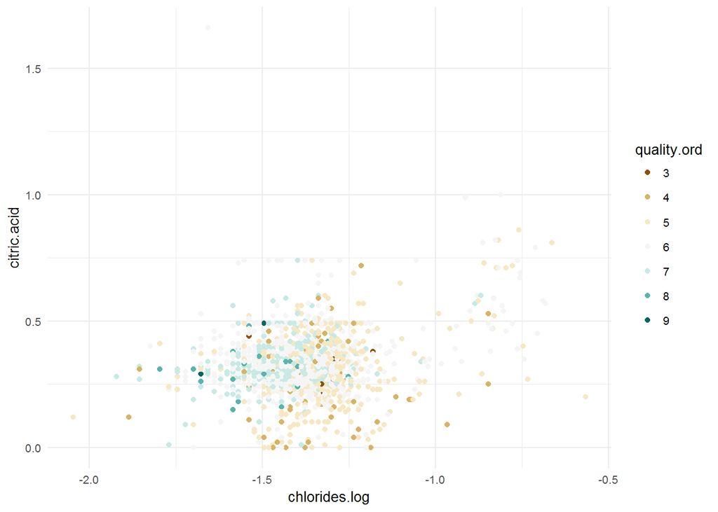

```
## [1] 0.2214095
```

When we focus on dry wine we can see that low alcohol and residual sugar under 1.5 g/l results in rather bad quality while high alcohol and residual sugar between 1.5 and 3 g/l favours outstanding quality

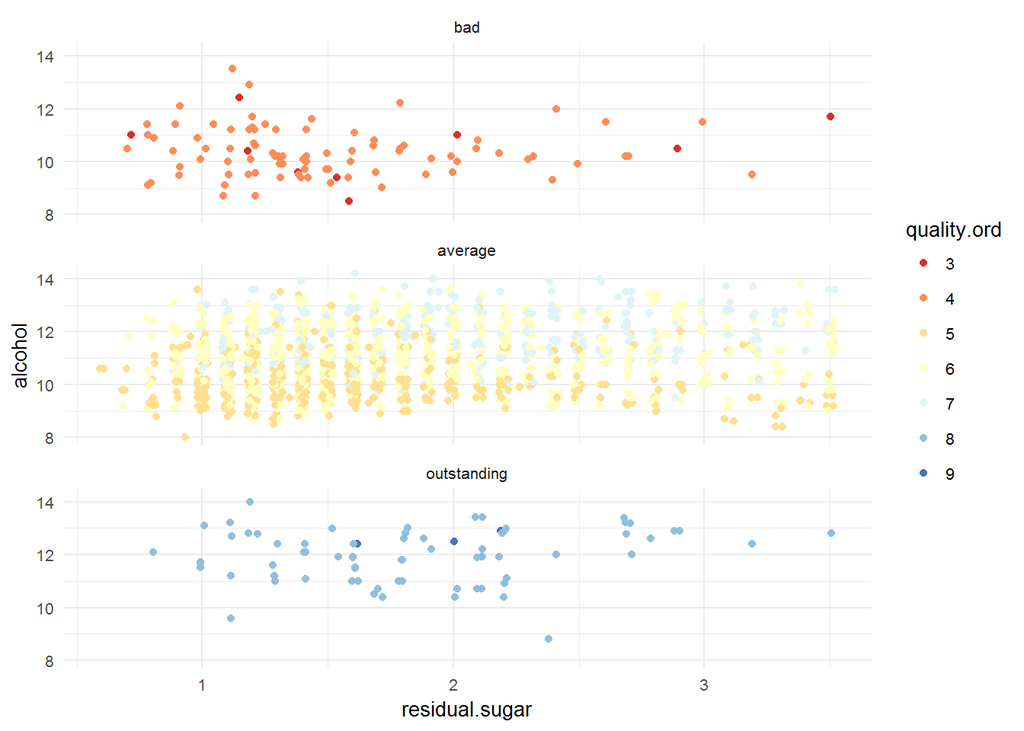

Especially when it comes to sweet wines, there is a strong positive relationship between residual sugar and density:

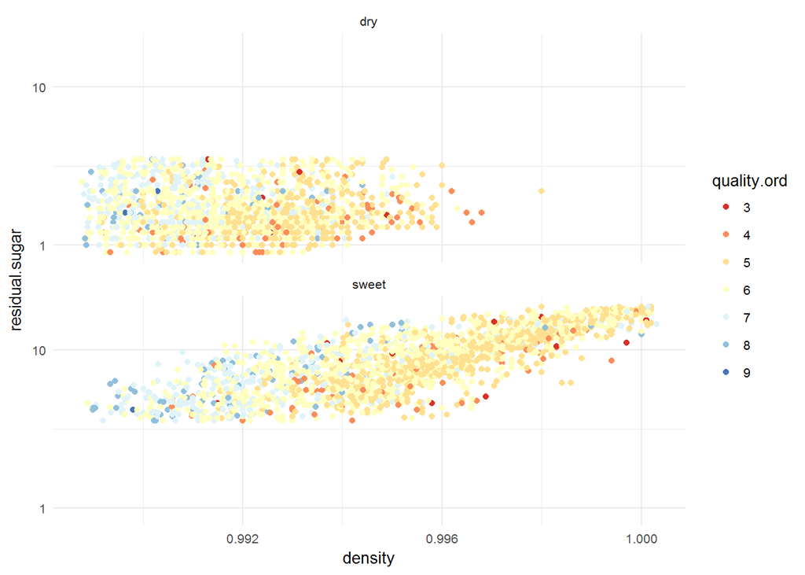

```
## [1] 0.8389665
```

As for the sweet wines high alcohol above 11 vol% results in rather outstanding quality. There is no clear picture if a certain residual sugar favours good or bad quality wine.

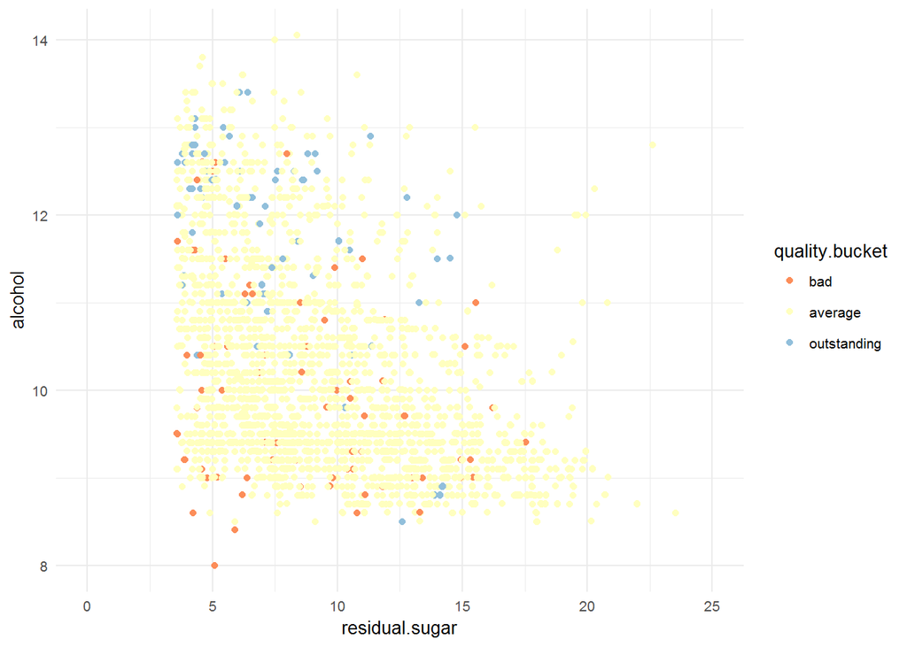

dry wines with pH value of 3.3 to 3.6 result in rather outstanding wines For sweet wines a citric acid between .25 and .50 allows also outstanding qulity for lower pH values down to 2.9

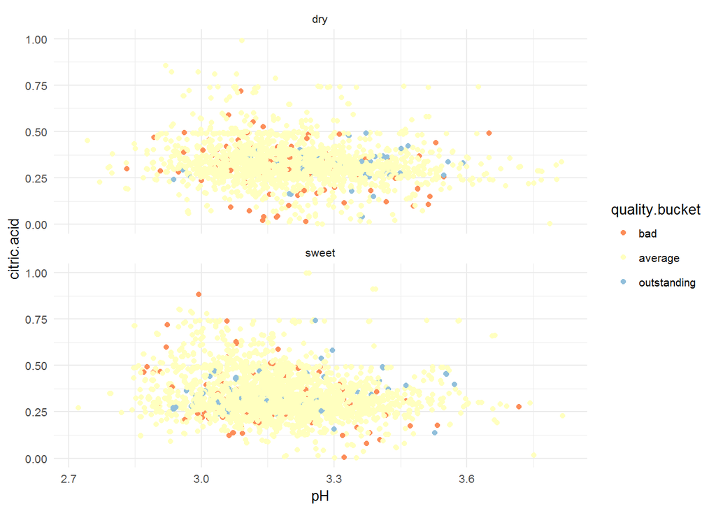

Different observations between outstanding and bad wine. High chlorides and low alcohol favour bad wines.

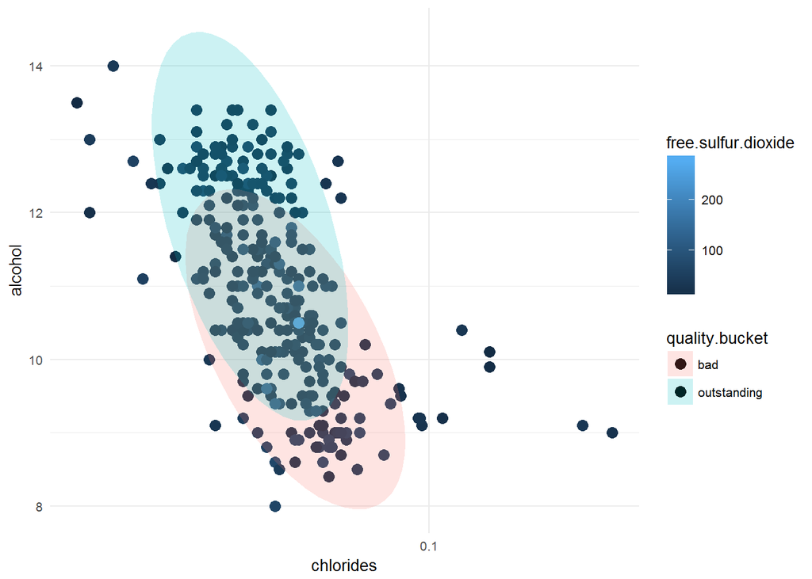

# Multivariate Analysis

### Were there any interesting or surprising interactions between features?

Most observations stop at abount 70 free sulfur dioxide but have a broader range of bound sulfur dioxide from 50 to 200. High citric acid combined with low chlorides seem to have a positive impact on quality.

### OPTIONAL: Did you create any models with your dataset? Discuss the strengths and limitations of your model.

I decided to go for a logistic regression model. Well the idea is either to have an outstanding wine or at least avoid a bad taste. That’s a binominal dependent variable which would fit the logistic regression model. Therefore I create the new binary variables taste.top and taste.bad

source: https://www.analyticsvidhya.com/blog/2015/11/beginners-guide-on-logistic-regression-in-r/

```
## 'data.frame':    4898 obs. of  19 variables:
##  $ fixed.acidity        : num  7 6.3 8.1 7.2 7.2 8.1 6.2 7 6.3 8.1 ...
##  $ volatile.acidity     : num  0.27 0.3 0.28 0.23 0.23 0.28 0.32 0.27 0.3 0.22 ...
##  $ citric.acid          : num  0.36 0.34 0.4 0.32 0.32 0.4 0.16 0.36 0.34 0.43 ...
##  $ residual.sugar       : num  20.7 1.6 6.9 8.5 8.5 6.9 7 20.7 1.6 1.5 ...
##  $ chlorides            : num  0.045 0.049 0.05 0.058 0.058 0.05 0.045 0.045 0.049 0.044 ...
##  $ free.sulfur.dioxide  : num  45 14 30 47 47 30 30 45 14 28 ...
##  $ total.sulfur.dioxide : num  170 132 97 186 186 97 136 170 132 129 ...
##  $ density              : num  1.001 0.994 0.995 0.996 0.996 ...
##  $ pH                   : num  3 3.3 3.26 3.19 3.19 3.26 3.18 3 3.3 3.22 ...
##  $ sulphates            : num  0.45 0.49 0.44 0.4 0.4 0.44 0.47 0.45 0.49 0.45 ...
##  $ alcohol              : num  8.8 9.5 10.1 9.9 9.9 10.1 9.6 8.8 9.5 11 ...
##  $ quality              : int  6 6 6 6 6 6 6 6 6 6 ...
##  $ quality.ord          : Ord.factor w/ 7 levels "3"<"4"<"5"<"6"<..: 4 4 4 4 4 4 4 4 4 4 ...
##  $ quality.bucket       : Ord.factor w/ 3 levels "bad"<"average"<..: 2 2 2 2 2 2 2 2 2 2 ...
##  $ residual.sugar.bucket: Factor w/ 2 levels "dry","sweet": 2 1 2 2 2 2 2 2 1 1 ...
##  $ chlorides.log        : num  -1.35 -1.31 -1.3 -1.24 -1.24 ...
##  $ bound.sulfur.dioxide : num  125 118 67 139 139 67 106 125 118 101 ...
##  $ taste.top            : Factor w/ 2 levels "N","Y": 1 1 1 1 1 1 1 1 1 1 ...
##  $ taste.bad            : Factor w/ 2 levels "Y","N": 2 2 2 2 2 2 2 2 2 2 ...
```

```
##  [1] "fixed.acidity"         "volatile.acidity"
##  [3] "citric.acid"           "residual.sugar"
##  [5] "chlorides"             "free.sulfur.dioxide"
##  [7] "total.sulfur.dioxide"  "density"
##  [9] "pH"                    "sulphates"
## [11] "alcohol"               "quality"
## [13] "quality.ord"           "quality.bucket"
## [15] "residual.sugar.bucket" "chlorides.log"
## [17] "bound.sulfur.dioxide"  "taste.top"
## [19] "taste.bad"
```

```
##
## Calls:
## m1: glm(formula = I(taste.top) ~ I(alcohol), family = binomial, data = dry.wine)
## m2: glm(formula = I(taste.top) ~ I(alcohol) + free.sulfur.dioxide,
##     family = binomial, data = dry.wine)
## m3: glm(formula = I(taste.top) ~ I(alcohol) + free.sulfur.dioxide +
##     I(log10(residual.sugar)), family = binomial, data = dry.wine)
## m4: glm(formula = I(taste.top) ~ I(alcohol) + free.sulfur.dioxide +
##     I(log10(residual.sugar)) + citric.acid, family = binomial,
##     data = dry.wine)
## m5: glm(formula = I(taste.top) ~ I(alcohol) + free.sulfur.dioxide +
##     I(log10(residual.sugar)) + citric.acid + pH, family = binomial,
##     data = dry.wine)
## m6: glm(formula = I(taste.top) ~ I(alcohol) + free.sulfur.dioxide +
##     I(log10(residual.sugar)) + citric.acid + pH + chlorides.log,
##     family = binomial, data = dry.wine)
##
## ==========================================================================================================
##                                 m1           m2           m3           m4           m5           m6
## ----------------------------------------------------------------------------------------------------------
##   (Intercept)                -12.628***   -13.364***   -13.331***   -13.188***   -24.476***   -25.188***
##                               (1.367)      (1.421)      (1.430)      (1.517)      (3.233)      (3.342)
##   I(alcohol)                   0.816***     0.835***     0.829***     0.826***     0.866***     0.818***
##                               (0.114)      (0.116)      (0.120)      (0.120)      (0.122)      (0.135)
##   free.sulfur.dioxide                       0.016**      0.016**      0.016**      0.013*       0.014*
##                                            (0.006)      (0.006)      (0.006)      (0.006)      (0.006)
##   I(log10(residual.sugar))                               0.162        0.145        0.113        0.196
##                                                         (0.825)      (0.827)      (0.855)      (0.857)
##   citric.acid                                                        -0.321        0.384        0.487
##                                                                      (1.167)      (1.082)      (1.062)
##   pH                                                                               3.286***     3.262***
##                                                                                   (0.793)      (0.796)
##   chlorides.log                                                                                -0.896
##                                                                                                (1.051)
## ----------------------------------------------------------------------------------------------------------
##   Aldrich-Nelson R-sq.         0.028        0.031        0.031        0.031        0.039        0.039
##   McFadden R-sq.               0.091        0.102        0.102        0.102        0.129        0.130
##   Cox-Snell R-sq.              0.028        0.031        0.031        0.031        0.040        0.040
##   Nagelkerke R-sq.             0.104        0.117        0.117        0.117        0.147        0.148
##   phi                          1.000        1.000        1.000        1.000        1.000        1.000
##   Likelihood-ratio            56.857       63.688       63.727       63.804       80.719       81.453
##   p                            0.000        0.000        0.000        0.000        0.000        0.000
##   Log-likelihood            -284.811     -281.395     -281.376     -281.337     -272.879     -272.513
##   Deviance                   569.621      562.790      562.752      562.674      545.759      545.025
##   AIC                        573.621      568.790      570.752      572.674      557.759      559.025
##   BIC                        584.821      585.590      593.151      600.674      591.358      598.224
##   N                         1998         1998         1998         1998         1998         1998
## ==========================================================================================================
```

```
##
## Calls:
## m1: glm(formula = I(taste.bad) ~ I(alcohol), family = binomial, data = sweet.wine)
## m2: glm(formula = I(taste.bad) ~ I(alcohol) + free.sulfur.dioxide,
##     family = binomial, data = sweet.wine)
## m3: glm(formula = I(taste.bad) ~ I(alcohol) + free.sulfur.dioxide +
##     I(log10(residual.sugar)), family = binomial, data = sweet.wine)
## m4: glm(formula = I(taste.bad) ~ I(alcohol) + free.sulfur.dioxide +
##     I(log10(residual.sugar)) + citric.acid, family = binomial,
##     data = sweet.wine)
## m5: glm(formula = I(taste.bad) ~ I(alcohol) + free.sulfur.dioxide +
##     I(log10(residual.sugar)) + citric.acid + pH, family = binomial,
##     data = sweet.wine)
## m6: glm(formula = I(taste.bad) ~ I(alcohol) + free.sulfur.dioxide +
##     I(log10(residual.sugar)) + citric.acid + pH + chlorides.log,
##     family = binomial, data = sweet.wine)
##
## ========================================================================================================
##                                m1          m2           m3           m4           m5           m6
## --------------------------------------------------------------------------------------------------------
##   (Intercept)                  1.630     -2.151       -5.186***    -5.091***    -7.623**     -8.385**
##                               (1.010)    (1.153)      (1.501)      (1.513)      (2.957)      (2.915)
##   I(alcohol)                   0.183      0.380***     0.515***     0.518***     0.511***     0.372**
##                               (0.101)    (0.107)      (0.117)      (0.117)      (0.117)      (0.127)
##   free.sulfur.dioxide                     0.053***     0.048***     0.049***     0.047***     0.049***
##                                          (0.008)      (0.008)      (0.008)      (0.008)      (0.008)
##   I(log10(residual.sugar))                             1.995**      2.057**      2.164**      2.043**
##                                                       (0.642)      (0.651)      (0.659)      (0.655)
##   citric.acid                                                      -0.588       -0.442       -0.610
##                                                                    (0.901)      (0.913)      (0.922)
##   pH                                                                             0.788        0.643
##                                                                                 (0.792)      (0.795)
##   chlorides.log                                                                              -2.052**
##                                                                                              (0.719)
## --------------------------------------------------------------------------------------------------------
##   Aldrich-Nelson R-sq.         0.001      0.017        0.021        0.021        0.021        0.023
##   McFadden R-sq.               0.005      0.065        0.078        0.078        0.080        0.089
##   Cox-Snell R-sq.              0.001      0.017        0.021        0.021        0.021        0.024
##   Nagelkerke R-sq.             0.005      0.074        0.088        0.088        0.090        0.100
##   phi                          1.000      1.000        1.000        1.000        1.000        1.000
##   Likelihood-ratio             3.542     50.909       60.738       61.154       62.158       69.335
##   p                            0.060      0.000        0.000        0.000        0.000        0.000
##   Log-likelihood            -388.981   -365.298     -360.383     -360.175     -359.673     -356.085
##   Deviance                   777.963    730.596      720.767      720.351      719.346      712.169
##   AIC                        781.963    736.596      728.767      730.351      731.346      726.169
##   BIC                        793.908    754.513      752.657      760.213      767.181      767.977
##   N                         2900       2900         2900         2900         2900         2900
## ========================================================================================================
```

# Final Plots and Summary

### Plot One

Feedback: The figures in the final plot section should be polished, please add the units to the axis labels and legends, for example, “Alcohol[%]”

Feedback: “For final plot 1, please choose a sequential color map.”

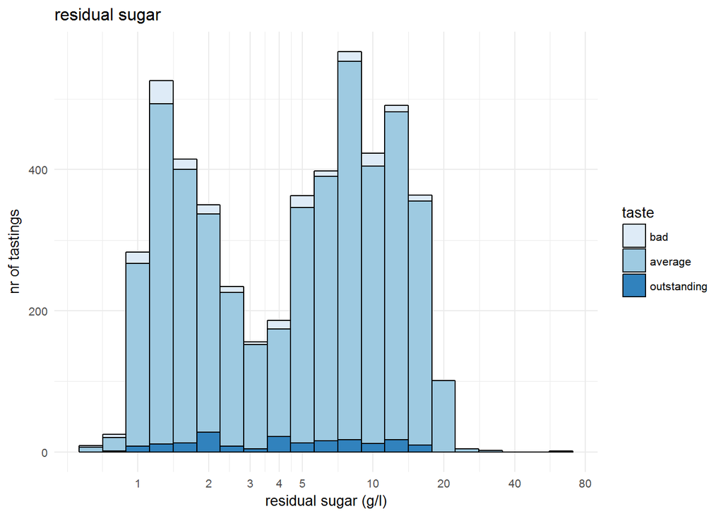

### Description One

There is a bimodal distribution in residual sugar. This can be explained by the fact that there are dry (completly fermented) and sweet white wines available. They taste very different and target different audiences. We will have to consider this in further analysis.

### Plot Two

Feedback: “For final plot 2, including more than 3 features in a single figure might be difficult to interpret in this dataset. In this case, it is difficult to separate the different alcohol percentage. Please consider the following instead.”

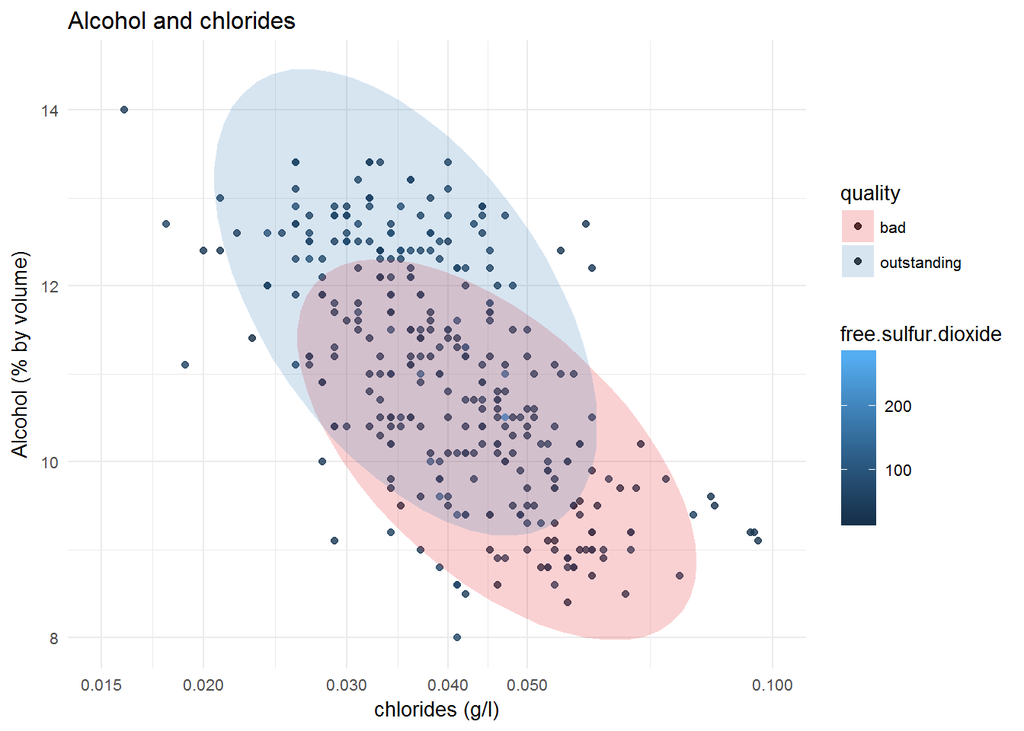

### Plot Three

Feedback: “Optional, for final plot 3 please consider adding regression lines to show the separation between categories.”

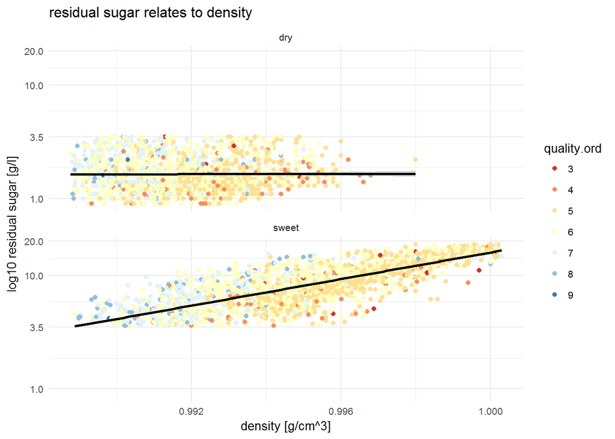

### Description Three

Looking at sweet wines with residual sugar above 3.5 we can clearly see a strong positive linear relationship between residual sugar and density. This relationship does not exists for dry wines below 3.5 residual sugar.

# Reflection

Feedback: “Please expand the reflection section to discuss also the struggles and successes throughout the analysis and at least one idea or question for future work.”

The initial challenge was to deal with the quality scale. It’s hard to begin with analyzing the data. I used the ggpairs function quite often to get an overview about all the relationships within the data set.

You have to take some domain knowledge into account to visualize the data in a way where you can make such decisions like putting the wine into quality buckets and split the data into sweet and dry wines.

One surprising finding was that low alcohol wine hardly makes it to outstanding taste quality. At the end I was quite happy to find some patterns in the data but it’s still hard to tell what makes a good or a bad wine by just looking at the physicochemical properties.

I was struggling how to deal with average quality wines. So I decided to focus mainly on bad and outstanding wines and find correlations focused on those two categories. This turned out to be a good idea to reduce the noise in the data.

Further analysis could focus on just one quality criteria for what makes white wine a bad wine only.